# Working with National Land Cover Database (NLCD) in R: Raster package and treemaps with ggplot2

### Math with maps: Quantifying land change with raster data

Raster is faster. The beauty of working with rasters is that a raster object functions just like a regular dataframe. It essentially has three attributes for each data point: An x position, a y position and the value itself. But stored as a single gridded image, it’s much more friendly to work with than a vector file. It may look like a pixelated generalization of realiy. It kind of is. But this image is soaked with information - and, we can do math on it.

So let’s explore some basics of Routt County land cover change with the information embedded in our NLCD raster stack.

And in the process, we’re going to learn a handy technique that you saw in the animation section: the **for loop.**

```r
# We have this data frame of NLCD classes:

df
```

```
##         class code                  description   color
## 1       water   11                   Open Water #476BA0
## 2       water   12           Perennial Ice/Snow #D1DDF9
## 3   developed   21        Developed, Open Space #DDC9C9
## 4   developed   22     Developed, Low Intensity #D89382
## 5   developed   23  Developed, Medium Intensity #ED0000
## 6   developed   24    Developed, High Intensity #AA0000
## 7      barren   31 Barren Land (Rock/Sand/Clay) #B2ADA3
## 8      forest   41             Deciduous Forest #68AA63
## 9      forest   42             Evergreen Forest #1C6330
## 10     forest   43                 Mixed Forest #B5C98E
## 12  shrubland   52                  Scrub/Shrub #CCBA7C
## 13 herbaceous   71         Grassland/Herbaceous #E2E2C1
## 17    planted   81                  Pasture/Hay #DBD83D
## 18    planted   82             Cultivated Crops #AA7028
## 19   wetlands   90               Woody Wetlands #BAD8EA
## 20   wetlands   95 Emergent Herbaceous Wetlands #70A3BA
```

```r
# And, using the freq() function, we can count the number of cells in each class.

freq(s[[1]])
```

```
##       value   count
##  [1,]    11   21074
##  [2,]    12     282
##  [3,]    21   37603
##  [4,]    22   14354
##  [5,]    23    3741
##  [6,]    24    1082
##  [7,]    31   12637
##  [8,]    41 2118121
##  [9,]    42 1575853
## [10,]    43  224290
## [11,]    52 2372042
## [12,]    71  116720
## [13,]    81  205291
## [14,]    82   26121
## [15,]    90   95329
## [16,]    95   59609
## [17,]    NA 3949394
```

```r
# So our goal: create a data frame (a table) where each row is a land cover class, and there is one column for each time step with the pixel count for each class. I find the greatest challenge of building a for loop is conceptualizing its structure.

# So I usually start by experimenting and finding a method that works on one layer:

test<-merge(df, freq(s[[1]]), by.x="code" ,by.y="value", all.y=F, all.x=T)
names(test)[ncol(test)]<-2001
test
```

```
##    code      class                  description   color    2001
## 1    11      water                   Open Water #476BA0   21074
## 2    12      water           Perennial Ice/Snow #D1DDF9     282
## 3    21  developed        Developed, Open Space #DDC9C9   37603
## 4    22  developed     Developed, Low Intensity #D89382   14354
## 5    23  developed  Developed, Medium Intensity #ED0000    3741
## 6    24  developed    Developed, High Intensity #AA0000    1082
## 7    31     barren Barren Land (Rock/Sand/Clay) #B2ADA3   12637
## 8    41     forest             Deciduous Forest #68AA63 2118121
## 9    42     forest             Evergreen Forest #1C6330 1575853
## 10   43     forest                 Mixed Forest #B5C98E  224290
## 11   52  shrubland                  Scrub/Shrub #CCBA7C 2372042
## 12   71 herbaceous         Grassland/Herbaceous #E2E2C1  116720
## 13   81    planted                  Pasture/Hay #DBD83D  205291
## 14   82    planted             Cultivated Crops #AA7028   26121
## 15   90   wetlands               Woody Wetlands #BAD8EA   95329
## 16   95   wetlands Emergent Herbaceous Wetlands #70A3BA   59609
```

```r
# OK, looks good. Now, we want to do this for each year. We could copy and paste and do the above for all seven layers.
# But what if we had 100 layers? What happens when we want to repeat this task on another dataset with different names?
# We need to automate, and we do that by looping through each layer to perform the task we wrote above.

# we'll make a vector of all the years in our study period, then loop through the positions (1-7), merging the frequency information into the data frame and naming the column after that year.


years<-c(2001, 2004, 2006, 2008, 2011, 2013, 2016)

d<-df
for (i in 1:length(years)) {
  d<-merge(d, freq(s[[i]]), by.x="code" ,by.y="value", all.y=F, all.x=T)
  names(d)[ncol(d)]<-paste0("pix_", years[[i]])
  }

# Now, a few percent change calculations:

d$square.mile.change<-(d$pix_2016 - d$pix_2001) * 30 * 30 * 0.00000038610
d$percentchange<-(d$pix_2016 - d$pix_2001)/d$pix_2001
d$prop2016<-d$pix_2016/sum(d$pix_2016)

d$percentchange.2001.2016<-paste(round(100*d$percentchange, 2), "%", sep="")
d$percent.area.2016<-paste(round(100*d$prop2016, 2), "%", sep="")

# Make it a pretty table with kable:


kable(d[,c(3,12,15,16)])  %>%
  kable_styling(bootstrap_options = c("striped", "hover"), full_width = F)
```

| description | square.mile.change | percentchange.2001.2016 | percent.area.2016 |
| --- | --- | --- | --- |
| Open Water | 1.0598445 | 14.47% | 0.35% |
| Perennial Ice/Snow | 0.0000000 | 0% | 0% |
| Developed, Open Space | 0.3301155 | 2.53% | 0.56% |
| Developed, Low Intensity | 0.2567951 | 5.15% | 0.22% |
| Developed, Medium Intensity | 0.2536677 | 19.51% | 0.06% |
| Developed, High Intensity | 0.0757528 | 20.15% | 0.02% |
| Barren Land (Rock/Sand/Clay) | -0.0368339 | -0.84% | 0.18% |
| Deciduous Forest | -2.0877199 | -0.28% | 30.68% |
| Evergreen Forest | -32.0427479 | -5.85% | 21.55% |
| Mixed Forest | -0.4566019 | -0.59% | 3.24% |
| Scrub/Shrub | 2.9488001 | 0.36% | 34.58% |
| Grassland/Herbaceous | 24.8292030 | 61.22% | 2.73% |
| Pasture/Hay | -1.3180296 | -1.85% | 2.93% |
| Cultivated Crops | 6.5727734 | 72.41% | 0.65% |
| Woody Wetlands | -0.0865250 | -0.26% | 1.38% |
| Emergent Herbaceous Wetlands | -0.2984939 | -1.44% | 0.85% |

```r
# And just for fun, aggregate it by class for another perspective

dfc<-aggregate(prop2016 ~ class, d[,c(2,13,14)], sum)
dfc$prop2016<-paste(round(100*dfc$prop2016, 2), "%", sep="")

kable(dfc)  %>%
  kable_styling(bootstrap_options = c("striped", "hover"), full_width = F)
```

| class | prop2016 |
| --- | --- |
| barren | 0.18% |
| developed | 0.86% |
| forest | 55.47% |
| herbaceous | 2.73% |
| planted | 3.58% |
| shrubland | 34.58% |
| water | 0.35% |
| wetlands | 2.23% |

### Death to the pie chart: Treemaps for proportional and hierarchical data visualization

For years, researchers in perception and data visualization have warned about the dangers of pie charts. The bottom line is this: Humans aren’t great at comparing the sizes of angular shapes, such as the slice of a pie. So if two pie slices are close together in size, it’s hard for us to tell which one is bigger.

Enter the treemap. Because you know what *is* easier for our eyes to compare? Rectangles. It’s that simple. Pie charts, but with rectangles. Treemaps are especially useful for visualizing hierarchical data. Here, we’ll look at Routt County land cover proportions with treemaps. The package `treemapify` enables plotting them through Ggplot. Next time someone asks you to make a pie chart, I hope you consider making one of these instead! Let’s make treemaps happen in mainstream data viz.

```r
# To start, we need to shift the data frame from "wide" format to "long" format, because GGplot likes it that way.
head(d)
```

```
##   code     class                 description   color pix_2001 pix_2004 pix_2006
## 1   11     water                  Open Water #476BA0    21074    21610    22257
## 2   12     water          Perennial Ice/Snow #D1DDF9      282      282      282
## 3   21 developed       Developed, Open Space #DDC9C9    37603    37603    38028
## 4   22 developed    Developed, Low Intensity #D89382    14354    14354    14727
## 5   23 developed Developed, Medium Intensity #ED0000     3741     3741     3995
## 6   24 developed   Developed, High Intensity #AA0000     1082     1082     1124
##   pix_2008 pix_2011 pix_2013 pix_2016 square.mile.change percentchange
## 1    22630    22660    22828    24124         1.05984450    0.14472810
## 2      282      282      282      282         0.00000000    0.00000000
## 3    38028    38472    38472    38553         0.33011550    0.02526394
## 4    14727    15020    15020    15093         0.25679511    0.05148391
## 5     3995     4382     4382     4471         0.25366770    0.19513499
## 6     1124     1269     1269     1300         0.07575282    0.20147874
##       prop2016 percentchange.2001.2016 percent.area.2016
## 1 3.504282e-03                  14.47%             0.35%
## 2 4.096367e-05                      0%                0%
## 3 5.600256e-03                   2.53%             0.56%
## 4 2.192428e-03                   5.15%             0.22%
## 5 6.494630e-04                  19.51%             0.06%
## 6 1.888396e-04                  20.15%             0.02%
```

```r
dn<- melt(d, id.vars = 1:4)

# Check out what that did - see how all of the land cover types are in one column now?
dn$value<-as.numeric(dn$value)
head(dn)
```

```
##   code     class                 description   color variable value
## 1   11     water                  Open Water #476BA0 pix_2001 21074
## 2   12     water          Perennial Ice/Snow #D1DDF9 pix_2001   282
## 3   21 developed       Developed, Open Space #DDC9C9 pix_2001 37603
## 4   22 developed    Developed, Low Intensity #D89382 pix_2001 14354
## 5   23 developed Developed, Medium Intensity #ED0000 pix_2001  3741
## 6   24 developed   Developed, High Intensity #AA0000 pix_2001  1082
```

```r
# For this first treemap, we want to summarize the land cover area by class, not individual description. So we need to aggregate by adding all of the values for each class together.

dc<-aggregate(value ~ class, dn[dn$variable=="pix_2016",], sum)
head(dc)
```

```
##        class   value
## 1     barren   12531
## 2  developed   59417
## 3     forest 3818730
## 4 herbaceous  188173
## 5    planted  246534
## 6  shrubland 2380528
```

```r
# Here are the colors from the palette dataframe in the order we'll need them for this plot. I also made a vector of labels so that I could format them exactly the way I want.

class_pal<-c("#B2ADA3", "#ED0000", "#68AA63", "#B5C98E", "#DBD83D", "#CCBA7C", "#476BA0", "#BAD8EA" )
class_labels<-c("barren", "developed", "forest", "grassland", "agriculture", "shrubland", "water", "wetlands")
```

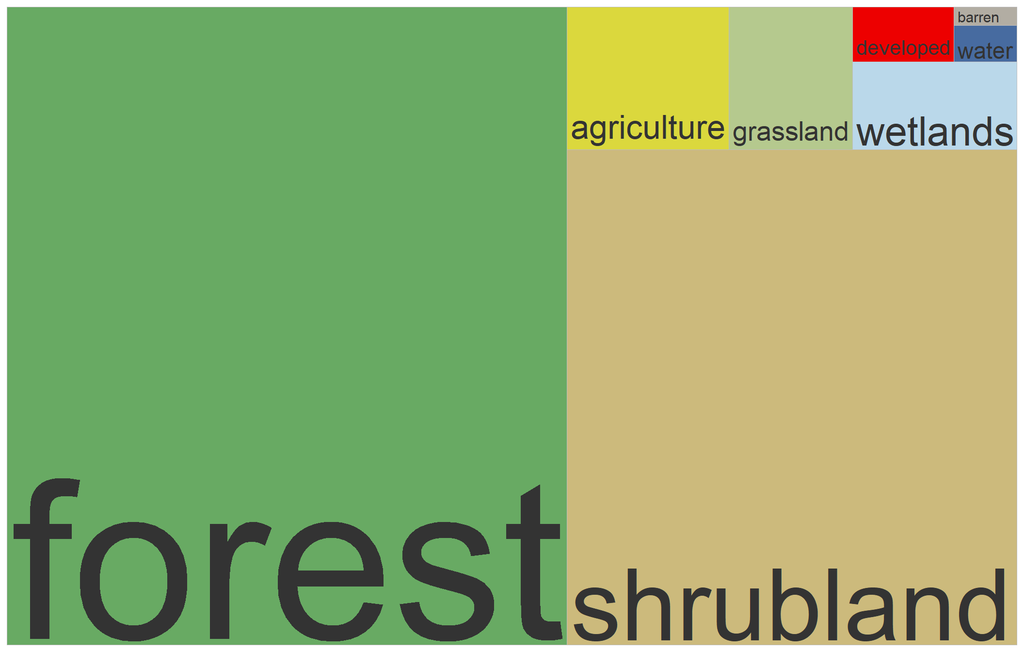

```r
# Treemaps are pretty straightforward in Ggplot. The relevant aesthetics are area, fill and label.
# Area is the size of the box - assign that to the area value in your dataframe.
# Fill is the color of the box. In this example we want the color to correspond to land cover class.
# Assign the label vector from above to the label aesthetic.


c<-ggplot(dc, aes(area=value, fill=class, label=class_labels)) +
  geom_treemap() +
 geom_treemap_text(grow=T, color="grey20", place="bottomleft")+
  scale_fill_manual(values=class_pal)+
  theme(legend.position = "none")
c
```

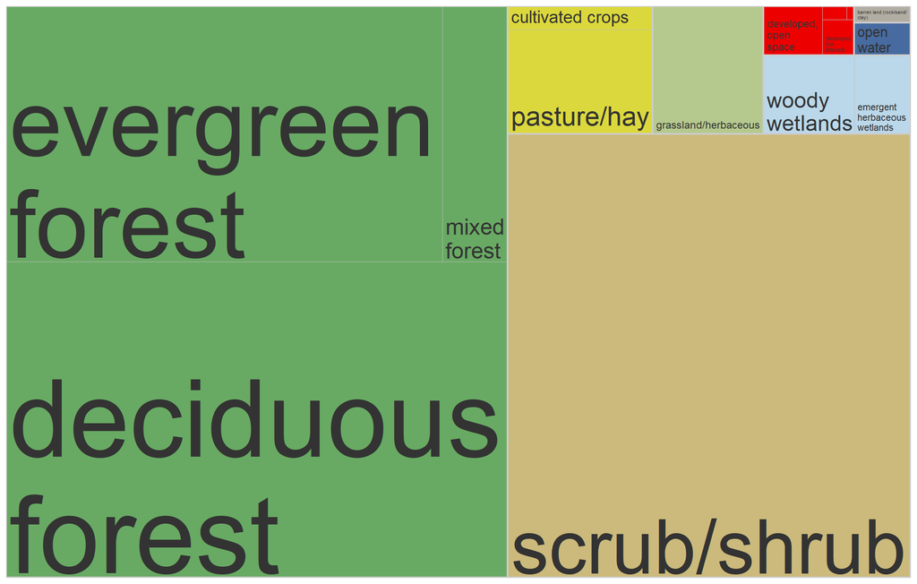

```r
# Treemaps are ideal for hierarchical data. In this instance, we want to keep the colors for the aggregated classes, but break each box down by land cover description. We do this by adding the "subgroup" argument.

t<-ggplot(dn[dn$variable=="pix_2016",], aes(area=value, fill=class, subgroup=class, label=tolower(description))) +
  geom_treemap() +
  geom_treemap_text(grow=T, color="grey20", place="bottomleft", reflow=T) +
  scale_fill_manual(values=class_pal)+
  theme(legend.position = 'none')+
  geom_treemap_subgroup_border(color="grey80", size=2)

t
```

We went over a LOT in this tutorial. Basic raster functions, levelplots, for loops, animations and treemaps. If you have any questions at all, feel free to [email me!](https://www.smalltownbigdata.com/contact)

**Next post drops March 2.**